# A Short Introduction to the caret Package Tutorial

This notebook comes from A Short Introduction to the caret Package By Max Kuhn, August 6, 2015

install caret:

```r
install.packages("caret", dependencies = c("Depends", "Suggests"))
```

```
Error in install.packages : Updating loaded packages
```

Load libraries:

```r
library(caret)
library(mlbench)
```

Load the Sonar data

```r
data(Sonar)
```

The goal is to predict the two classes (M for metal cylinder or R for rock)

First split the data into two groups: a training set and a test set using the createDataPartition function

```r
set.seed(107)
inTrain <- createDataPartition(y = Sonar$Class,
                                            ## the outcome data are needed
                                            p = .75,
                                            ## The percentage of data in the
                                            ## training set
                                            list = FALSE)
                                            ## the format of the results

## The output is a set of integers for the rows of Sonar
## that belong in the training set.
str(inTrain)
```

```
 int [1:157, 1] 1 2 3 4 5 7 10 11 12 13 ...
 - attr(*, "dimnames")=List of 2
  ..$ : NULL
  ..$ : chr "Resample1"
```

By default, createDataPartition does a stratified random split of the data. To partition the data:

```r
training <- Sonar[ inTrain,]
testing  <- Sonar[-inTrain,]
nrow(training)
```

```
[1] 157
```

```r
nrow(testing)
```

```
[1] 51
```

Tune a partial least squares discriminant analysis (PLSDA) model over the number of PLS components that should be retained:

Basic syntax:

```r
plsFit <- train(Class ~ .,
                data = training,
                method = "pls",
                ## Center and scale the predictors for the training
                ## set and all future samples.
                preProc = c("center", "scale"))
```

By default, the function will tune over three values of each tuning parameter.

The simple bootstrap is used by default. Next example uses three repeats of 10-fold cross validation

If unspecified, overall accuracy and the Kappa statistic are computed. For regression models, root mean squared error and R2 are computed. Next example will be altered to estimate the area under the ROC curve, the sensitivity and specificity.

Use tuneLength or tuneGrid arguments to change the candidate values of the tuning parameters:

```r
plsFit <- train(Class ~ .,
                data = training,
                method = "pls",
                tuneLength = 15,
                ##this one is new compared to the first example
                preProc = c("center", "scale"))
```

Modify the resampling method using trainControl function.

method option controls the type of resampling, default is “boot”

repeatedcv used to specify repeated K-fold cross-validation, “repeats” for the number of repititions.

“number” controls K and defaults to 10

```r
ctrl <- trainControl (method = "repeatedcv",
                      repeats = 3)
plsFit <- train(Class ~ .,
                data = training,
                method = "pls",
                tuneLength = 15,
                trControl = ctrl,
                preProc = c("center","scale"))
```

Choose different measures of performance using additional arguments to trainControl. summaryFunction is used to pass a function that takes observed and predicted values and estimates some measure of performance. defaultSummary or twoClassSummary. twoClassSummary computes measures specific to two-class problemsn, like the area under the ROC curve, sensitivity, and specificity. Another option is required because ROC curve is based on the predicted class probablilityes. classProbs = TRUE is used to include that.

Because custome performance measures are used, we have to specify what criteria will be optimized. In train, use metric = “ROC” for that.

```r
ctrl <- trainControl(method = "repeatedcv",
                     repeats = 3,
                     classProbs = TRUE,
                     summaryFunction = twoClassSummary)
plsFit <- train(Class ~ .,
                data = training,
                method = "pls",
                tuneLength = 15,
                trControl = ctrl,
                metric = "ROC",
                preProc = c("center", "scale"))
install.packages("caret", dependencies = c("Depends", "Suggests"))
```

Show plsFit

```r
plsFit
```

```
Partial Least Squares

157 samples
 60 predictor
  2 classes: 'M', 'R'

Pre-processing: centered (60), scaled (60)
Resampling: Cross-Validated (10 fold, repeated 3 times)
Summary of sample sizes: 142, 141, 141, 141, 141, 141, ...
Resampling results across tuning parameters:

  ncomp  ROC        Sens       Spec
   1     0.8259425  0.7337963  0.7142857
   2     0.8683201  0.7689815  0.7916667
   3     0.8675926  0.7810185  0.7482143
   4     0.8589782  0.7925926  0.7535714
   5     0.8338955  0.7726852  0.7535714
   6     0.8118552  0.7518519  0.7190476
   7     0.8019097  0.7449074  0.6994048
   8     0.8075231  0.7449074  0.7089286
   9     0.8020172  0.7560185  0.6994048
  10     0.7912202  0.7486111  0.7053571
  11     0.7940724  0.7476852  0.7089286
  12     0.7843337  0.7444444  0.7232143
  13     0.7779597  0.7472222  0.7184524
  14     0.7734871  0.7518519  0.7041667
  15     0.7758598  0.7513889  0.7077381

ROC was used to select the optimal model using the largest value.
The final value used for the model was ncomp = 2.
```

Visualize the results

```r
plsClasses <- predict(plsFit, newdata = testing)
str(plsClasses)
```

```
 Factor w/ 2 levels "M","R": 2 1 1 2 2 2 2 2 2 2 ...
```

```r
plsProbs <- predict(plsFit, newdata = testing, type = "prob")
head(plsProbs)
```

|  | M | R |
| --- | --- | --- |
| 6 | 0.3526672 | 0.6473328 |
| 8 | 0.5916628 | 0.4083372 |
| 9 | 0.5851591 | 0.4148409 |
| 15 | 0.4297217 | 0.5702783 |
| 26 | 0.4023577 | 0.5976423 |
| 27 | 0.4527808 | 0.5472192 |

[output not shown]

6 rows

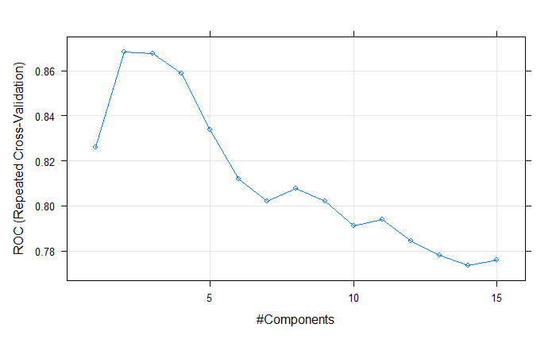

```r
plot(plsFit)
```

plot(plsFit) shows the relationship between the number of PLS components and the resampled estimate of the area under the ROC curve.

```r
confusionMatrix(data = plsClasses, testing$Class)
```

```
Confusion Matrix and Statistics

          Reference
Prediction  M  R
         M 21  6
         R  6 18

               Accuracy : 0.7647
                 95% CI : (0.6251, 0.8721)
    No Information Rate : 0.5294
    P-Value [Acc > NIR] : 0.0004667

                  Kappa : 0.5278

 Mcnemar's Test P-Value : 1.0000000

            Sensitivity : 0.7778
            Specificity : 0.7500
         Pos Pred Value : 0.7778
         Neg Pred Value : 0.7500
             Prevalence : 0.5294
         Detection Rate : 0.4118
   Detection Prevalence : 0.5294
      Balanced Accuracy : 0.7639

       'Positive' Class : M
```

Try training another model In this case, a regularized discriminant model

```r
## To illustrate, a custom grid is used
rdaGrid = data.frame(gamma = (0:4)/4, lambda = 3/4)
set.seed(123)
rdaFit <- train(Class ~ .,
                data = training,
                method = "rda",
                tuneGrid = rdaGrid,
                trControl = ctrl,
                metric = "ROC")
```

```r
rdaFit
```

```
Regularized Discriminant Analysis

157 samples
 60 predictor
  2 classes: 'M', 'R'

No pre-processing
Resampling: Cross-Validated (10 fold, repeated 3 times)
Summary of sample sizes: 141, 141, 142, 142, 141, 142, ...
Resampling results across tuning parameters:

  gamma  ROC        Sens       Spec
  0.00   0.7775876  0.7231481  0.6815476
  0.25   0.8865989  0.8643519  0.7863095
  0.50   0.8764964  0.8513889  0.7303571
  0.75   0.8633185  0.8300926  0.7095238
  1.00   0.7338872  0.6800926  0.6357143

Tuning parameter 'lambda' was held constant at a value of 0.75
ROC was used to select the optimal model using the largest value.
The final values used for the model were gamma = 0.25 and lambda = 0.75.
```

```r
rdaClasses <- predict(rdaFit, newdata = testing)
```

```r
confusionMatrix(rdaClasses, testing$Class)
```

```
Confusion Matrix and Statistics

          Reference
Prediction  M  R
         M 25  5
         R  2 19

               Accuracy : 0.8627
                 95% CI : (0.7374, 0.943)
    No Information Rate : 0.5294
    P-Value [Acc > NIR] : 5.008e-07

                  Kappa : 0.7226

 Mcnemar's Test P-Value : 0.4497

            Sensitivity : 0.9259
            Specificity : 0.7917
         Pos Pred Value : 0.8333
         Neg Pred Value : 0.9048
             Prevalence : 0.5294
         Detection Rate : 0.4902
   Detection Prevalence : 0.5882
      Balanced Accuracy : 0.8588

       'Positive' Class : M
```

The resamples function can be used to collect, summarize and contrast the resampling results.

```r
resamps <- resamples(list(pls = plsFit, rda = rdaFit))
```

```r
summary(resamps)
```

```
Call:
summary.resamples(object = resamps)

Models: pls, rda
Number of resamples: 30

ROC
         Min.   1st Qu.    Median      Mean   3rd Qu.     Max. NA's
pls 0.5873016 0.8263889 0.8730159 0.8683201 0.9614955 0.984375    0
rda 0.7500000 0.8470982 0.8888889 0.8865989 0.9404762 1.000000    0

Sens
         Min.   1st Qu.    Median      Mean 3rd Qu. Max. NA's
pls 0.4444444 0.6875000 0.7777778 0.7689815   0.875    1    0
rda 0.6250000 0.7569444 0.8750000 0.8643519   1.000    1    0

Spec
         Min.   1st Qu.    Median      Mean   3rd Qu. Max. NA's
pls 0.4285714 0.7142857 0.8571429 0.7916667 0.8571429    1    0
rda 0.5000000 0.7142857 0.7500000 0.7863095 0.8750000    1    0
```

Bland-Altman type plot to visualize the results

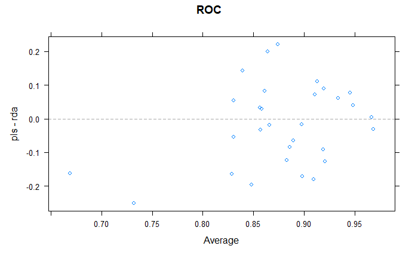

```r
xyplot(resamps, what = "BlandAltman")
```

```r
diffs <- diff(resamps)
summary(diffs)
```

```
Call:
summary.diff.resamples(object = diffs)

p-value adjustment: bonferroni
Upper diagonal: estimates of the difference
Lower diagonal: p-value for H0: difference = 0

ROC
    pls    rda
pls        -0.01828
rda 0.4128

Sens
    pls     rda
pls         -0.09537
rda 0.01451

Spec
    pls    rda
pls        0.005357
rda 0.9013
```